# R Notebook

```r
library(caret)
library(nnet)
library(rpart)
library(MLmetrics)
library(gbm)
library(randomForest)
library(xgboost)
library(Matrix)
```

```r
df <- read.csv("data_for_modeling_clean.csv")
head(df)
```

|  | MONTH | DAY_OF_WEEK | DEP_DEL15 | DISTANCE_GROUP | SEGMENT_NUMBER | NUMBER_OF_SEATS | GROUND_SERV_PER_PASS | PLANE_AGE | PRCP | SNOW | SNWD | TMAX | AWND | DEP_TIME_START |
| --- | --- | --- | --- | --- | --- | --- | --- | --- | --- | --- | --- | --- | --- | --- |
| 1 | 1 | 7 | 0 | 2 | 1 | 0.2599975 | 0.8354177 | -0.64948092 | -0.3045382 | -0.1029852 | -0.1264413 | -0.3577674 | -1.502734 | 6 |
| 2 | 1 | 7 | 0 | 7 | 2 | 0.8815979 | -0.7902490 | -1.22406594 | -0.3045382 | -0.1029852 | -0.1264413 | -0.3577674 | -1.502734 | 9 |
| 3 | 1 | 7 | 0 | 1 | 2 | 0.1956940 | -0.7902490 | 0.21239662 | -0.3045382 | -0.1029852 | -0.1264413 | -0.3577674 | -1.502734 | 9 |
| 4 | 1 | 7 | 0 | 7 | 2 | 1.2245499 | 0.2783801 | -1.22406594 | -0.3045382 | -0.1029852 | -0.1264413 | -0.3577674 | -1.502734 | 10 |
| 5 | 1 | 7 | 0 | 4 | 2 | -0.1043889 | -0.6002264 | -0.07489589 | -0.3045382 | -0.1029852 | -0.1264413 | -0.3577674 | -1.502734 | 7 |
| 6 | 1 | 7 | 0 | 10 | 2 | -0.1043889 | -0.1896039 | -0.07489589 | -0.3045382 | -0.1029852 | -0.1264413 | -0.3577674 | -1.502734 | 10 |

```r
# drop duplicates
df <- df[!duplicated(df), ]
dim(df)
```

```
[1] 64590    14
```

```r
str(df)
```

```
'data.frame':   64590 obs. of  14 variables:
 $ MONTH               : int  1 1 1 1 1 1 1 1 1 1 ...
 $ DAY_OF_WEEK         : int  7 7 7 7 7 7 7 5 5 5 ...
 $ DEP_DEL15           : int  0 0 0 0 0 0 0 0 1 0 ...
 $ DISTANCE_GROUP      : int  2 7 1 7 4 10 7 4 4 2 ...
 $ SEGMENT_NUMBER      : int  1 2 2 2 2 2 3 1 2 3 ...
 $ NUMBER_OF_SEATS     : num  0.26 0.882 0.196 1.225 -0.104 ...
 $ GROUND_SERV_PER_PASS: num  0.835 -0.79 -0.79 0.278 -0.6 ...
 $ PLANE_AGE           : num  -0.6495 -1.2241 0.2124 -1.2241 -0.0749 ...
 $ PRCP                : num  -0.305 -0.305 -0.305 -0.305 -0.305 ...
 $ SNOW                : num  -0.103 -0.103 -0.103 -0.103 -0.103 ...
 $ SNWD                : num  -0.126 -0.126 -0.126 -0.126 -0.126 ...
 $ TMAX                : num  -0.358 -0.358 -0.358 -0.358 -0.358 ...
 $ AWND                : num  -1.5 -1.5 -1.5 -1.5 -1.5 ...
 $ DEP_TIME_START      : int  6 9 9 10 7 10 12 6 10 12 ...
```

### Change the categorical data into factors

```r
categorical_var <- c("MONTH", "DAY_OF_WEEK", "DEP_DEL15", "DISTANCE_GROUP",
                      "SEGMENT_NUMBER", "DEP_TIME_START")
df[categorical_var] <- lapply(df[categorical_var], as.factor)
str(df)
```

```
'data.frame':   64590 obs. of  14 variables:
 $ MONTH               : Factor w/ 12 levels "1","2","3","4",..: 1 1 1 1 1 1 1 1 1 1 ...
 $ DAY_OF_WEEK         : Factor w/ 7 levels "1","2","3","4",..: 7 7 7 7 7 7 7 5 5 5 ...
 $ DEP_DEL15           : Factor w/ 2 levels "0","1": 1 1 1 1 1 1 1 1 2 1 ...
 $ DISTANCE_GROUP      : Factor w/ 11 levels "1","2","3","4",..: 2 7 1 7 4 10 7 4 4 2 ...
 $ SEGMENT_NUMBER      : Factor w/ 15 levels "1","2","3","4",..: 1 2 2 2 2 2 3 1 2 3 ...
 $ NUMBER_OF_SEATS     : num  0.26 0.882 0.196 1.225 -0.104 ...
 $ GROUND_SERV_PER_PASS: num  0.835 -0.79 -0.79 0.278 -0.6 ...
 $ PLANE_AGE           : num  -0.6495 -1.2241 0.2124 -1.2241 -0.0749 ...
 $ PRCP                : num  -0.305 -0.305 -0.305 -0.305 -0.305 ...
 $ SNOW                : num  -0.103 -0.103 -0.103 -0.103 -0.103 ...
 $ SNWD                : num  -0.126 -0.126 -0.126 -0.126 -0.126 ...
 $ TMAX                : num  -0.358 -0.358 -0.358 -0.358 -0.358 ...
 $ AWND                : num  -1.5 -1.5 -1.5 -1.5 -1.5 ...
 $ DEP_TIME_START      : Factor w/ 19 levels "1","6","7","8",..: 2 5 5 6 3 6 8 2 6 8 ...
```

### Train-Test Split. Train is to do cross validation (get the best hyperparamter), test is to evaluate each model with the best parameter

```r
set.seed(1234)

# stratified split
train_idx <- createDataPartition(df$DEP_DEL15, p = 0.8, list = FALSE)
train_data <- df[train_idx, ]
test_data <- df[-train_idx, ]
```

##### Standardize

```r
numeric_vars <- sapply(df, is.numeric)
train_mean <- colMeans(train_data[, numeric_vars], na.rm = TRUE)
train_sd <- apply(train_data[, numeric_vars], 2, sd, na.rm = TRUE)
train_data[, numeric_vars] <- scale(train_data[, numeric_vars], center = train_mean, scale = train_sd)

# scale the test data using the train mean and sd to prevent data leakage
test_data[, numeric_vars] <- scale(test_data[, numeric_vars], center = train_mean, scale = train_sd)
```

```r
model_results_df <- data.frame(
  Model = character(),
  Accuracy = numeric(),
  Precision = numeric(),
  Recall = numeric(),
  F1_Score = numeric(),
  stringsAsFactors = FALSE
)

# Function to add results
add_model_results <- function(model_name, acc, prec, rec, f1) {
  new_row <- data.frame(
    Model = model_name,
    Accuracy = round(acc, 4),
    Precision = round(prec, 4),
    Recall = round(rec, 4),
    F1_Score = round(f1, 4)
  )
  return(rbind(model_results_df, new_row))
}
```

### 1. Logistic Regression

```r
logistic <- glm(DEP_DEL15~., data = train_data, family = binomial)
summary(logistic)
```

```
Call:
glm(formula = DEP_DEL15 ~ ., family = binomial, data = train_data)

Coefficients:
                      Estimate Std. Error z value Pr(>|z|)
(Intercept)           -2.69666    0.12329 -21.873  < 2e-16 ***
MONTH2                 0.18398    0.05954   3.090 0.002001 **
MONTH3                 0.08735    0.05831   1.498 0.134134
MONTH4                 0.06054    0.06124   0.989 0.322845
MONTH5                 0.28055    0.06113   4.589 4.44e-06 ***
MONTH6                 0.56476    0.06272   9.004  < 2e-16 ***
MONTH7                 0.46135    0.06544   7.050 1.79e-12 ***
MONTH8                 0.43398    0.06501   6.676 2.46e-11 ***
MONTH9                -0.14614    0.06927  -2.110 0.034891 *
MONTH10               -0.03976    0.06271  -0.634 0.526055
MONTH11               -0.17878    0.06185  -2.891 0.003846 **
MONTH12                0.21836    0.05721   3.817 0.000135 ***
DAY_OF_WEEK2          -0.21067    0.04348  -4.845 1.27e-06 ***
DAY_OF_WEEK3          -0.13210    0.04272  -3.092 0.001987 **
DAY_OF_WEEK4           0.05013    0.04167   1.203 0.229001
DAY_OF_WEEK5           0.01346    0.04155   0.324 0.746042
DAY_OF_WEEK6          -0.15306    0.04506  -3.396 0.000683 ***
DAY_OF_WEEK7          -0.08782    0.04251  -2.066 0.038848 *
DISTANCE_GROUP2        0.01866    0.04324   0.432 0.666095
DISTANCE_GROUP3        0.03847    0.04473   0.860 0.389699
DISTANCE_GROUP4        0.17066    0.04729   3.609 0.000308 ***
DISTANCE_GROUP5        0.18433    0.05195   3.548 0.000388 ***
DISTANCE_GROUP6        0.30147    0.06560   4.595 4.32e-06 ***
DISTANCE_GROUP7        0.22019    0.06709   3.282 0.001031 **
DISTANCE_GROUP8        0.12446    0.08413   1.479 0.139034
DISTANCE_GROUP9        0.28989    0.09391   3.087 0.002022 **
DISTANCE_GROUP10       0.11417    0.07992   1.429 0.153118
DISTANCE_GROUP11       0.12152    0.08905   1.365 0.172361
SEGMENT_NUMBER2       -0.23595    0.04633  -5.093 3.53e-07 ***
SEGMENT_NUMBER3       -0.25568    0.05109  -5.004 5.61e-07 ***
SEGMENT_NUMBER4       -0.27494    0.05395  -5.097 3.46e-07 ***
SEGMENT_NUMBER5       -0.25031    0.05964  -4.197 2.71e-05 ***
SEGMENT_NUMBER6       -0.23899    0.06580  -3.632 0.000281 ***
SEGMENT_NUMBER7       -0.03361    0.08684  -0.387 0.698729
SEGMENT_NUMBER8       -0.29774    0.11134  -2.674 0.007491 **
```

[output cut: 28 more lines]

```
DEP_TIME_START19       1.77092    0.12335  14.357  < 2e-16 ***
DEP_TIME_START20       1.66047    0.12424  13.366  < 2e-16 ***
DEP_TIME_START21       1.75412    0.12851  13.649  < 2e-16 ***
DEP_TIME_START22       1.58676    0.13137  12.079  < 2e-16 ***
DEP_TIME_START23       1.18221    0.17302   6.833 8.33e-12 ***
---
Signif. codes:  0 ‘***’ 0.001 ‘**’ 0.01 ‘*’ 0.05 ‘.’ 0.1 ‘ ’ 1

(Dispersion parameter for binomial family taken to be 1)

    Null deviance: 50287  on 51672  degrees of freedom
Residual deviance: 47553  on 51605  degrees of freedom
AIC: 47689

Number of Fisher Scoring iterations: 9
```

We have filtered out our data using logistic regression and take all of the variables that is significant. That’s why in here, most of them are significant. I will retain them here to use the model fitting on the test part later on.

```r
logistic_probs <- predict(logistic, test_data, type = "response")
logistic_preds <- ifelse(logistic_probs > 0.5, 1, 0)

conf_matrix_logistic <- confusionMatrix(as.factor(logistic_preds), as.factor(test_data$DEP_DEL15), positive = "1")

# Extract performance metrics
logistic_accuracy <- conf_matrix_logistic$overall["Accuracy"]
logistic_precision <- conf_matrix_logistic$byClass["Precision"]
logistic_recall <- conf_matrix_logistic$byClass["Recall"]
logistic_f1 <- F1_Score(logistic_preds, test_data$DEP_DEL15, positive = "1")

# Print results
print(paste("Logistic Regression Test Accuracy:", round(logistic_accuracy, 4)))
```

```
[1] "Logistic Regression Test Accuracy: 0.8099"
```

```r
print(paste("Logistic Regression Test Precision:", round(logistic_precision, 4)))
```

```
[1] "Logistic Regression Test Precision: 0.5085"
```

```r
print(paste("Logistic Regression Test Recall:", round(logistic_recall, 4)))
```

```
[1] "Logistic Regression Test Recall: 0.0122"
```

```r
print(paste("Logistic Regression Test F1-Score:", round(logistic_f1, 4)))
```

```
[1] "Logistic Regression Test F1-Score: 0.0238"
```

```r
model_results_df <- add_model_results("Logistic Regression", logistic_accuracy, logistic_precision, logistic_recall, logistic_f1)
```

### 2. Neural Network

```r
neurons <- c(3, 5, 7)  # Number of hidden neurons
lambda <- c(0.001, 0.01, 0.1)  # Regularization (decay)
K <- 5  # Number of folds for cross-validation

# Store results
results <- expand.grid(size = neurons, decay = lambda, Accuracy = NA,
                       Precision = NA, Recall = NA, F1 = NA)

n <- nrow(train_data)
y <- train_data$DEP_DEL15  # Target variable

# Convert target variable to factor with explicit levels
train_data$DEP_DEL15 <- factor(train_data$DEP_DEL15, levels = c("0", "1"))

set.seed(1234)
cv_folds <- sample(rep(1:K, length.out = n))  # Randomly assign folds

for (i in 1:nrow(results)) {
  size <- results$size[i]
  decay <- results$decay[i]

  accuracy_list <- numeric(K)
  precision_list <- numeric(K)
  recall_list <- numeric(K)
  f1_list <- numeric(K)

  for (fold in 1:K) {
    train_idx <- which(cv_folds != fold)
    test_idx <- which(cv_folds == fold)

    # Train Neural Network
    nn_model <- nnet(DEP_DEL15 ~ ., data = train_data[train_idx, ], size = size,
                     decay = decay, maxit = 500, trace = FALSE)

    # Predict Class Labels
    nn_probs <- predict(nn_model, train_data[test_idx, ], type = "class")

    # Ensure Factor Levels Match
    nn_probs <- factor(nn_probs, levels = levels(train_data$DEP_DEL15))

    # Compute Confusion Matrix
    conf_matrix <- confusionMatrix(nn_probs, train_data$DEP_DEL15[test_idx], positive = "1")

    # Extract Performance Metrics
    accuracy_list[fold] <- conf_matrix$overall["Accuracy"]
    precision_list[fold] <- conf_matrix$byClass["Precision"]
    recall_list[fold] <- conf_matrix$byClass["Recall"]
    f1_list[fold] <- F1_Score(as.numeric(as.character(nn_probs)),
                              as.numeric(as.character(train_data$DEP_DEL15[test_idx])),
                              positive = "1")
  }

  # Store the averaged performance metrics across folds
  results$Accuracy[i] <- mean(accuracy_list)
  results$Precision[i] <- mean(precision_list)
  results$Recall[i] <- mean(recall_list)
  results$F1[i] <- mean(f1_list)
}
```

```r
results
```

| size | decay | Accuracy | Precision | Recall | F1 |
| --- | --- | --- | --- | --- | --- |
| 3 | 0.001 | 0.8106555 | 0.5426098 | 0.04130350 | 0.07633281 |
| 5 | 0.001 | 0.8089718 | 0.4782665 | 0.05218390 | 0.09391208 |
| 7 | 0.001 | 0.8074817 | 0.4553175 | 0.06063273 | 0.10688409 |
| 3 | 0.010 | 0.8094169 | 0.4880205 | 0.03758595 | 0.06973381 |
| 5 | 0.010 | 0.8093008 | 0.4853993 | 0.04223017 | 0.07763889 |
| 7 | 0.010 | 0.8084493 | 0.4715751 | 0.05210891 | 0.09355655 |
| 3 | 0.100 | 0.8112941 | 0.5479909 | 0.04624682 | 0.08523991 |
| 5 | 0.100 | 0.8108684 | 0.5299113 | 0.05171964 | 0.09419189 |
| 7 | 0.100 | 0.8100943 | 0.5078454 | 0.06416303 | 0.11385204 |

Best model based on F1 score is the model with size = 7 and decay = 0.1

```r
final_nn_model <- nnet(DEP_DEL15 ~ ., data = train_data,
                       size = 7, decay = 0.1, maxit = 500, trace = FALSE)
nn_probs <- predict(final_nn_model, test_data, type = "raw")
nn_preds <- ifelse(nn_probs > 0.5, 1, 0)

conf_matrix_nn <- confusionMatrix(as.factor(nn_preds), as.factor(test_data$DEP_DEL15), positive = "1")

nn_accuracy <- conf_matrix_nn$overall["Accuracy"]
nn_precision <- conf_matrix_nn$byClass["Precision"]
nn_recall <- conf_matrix_nn$byClass["Recall"]
nn_f1 <- F1_Score(nn_preds, test_data$DEP_DEL15, positive = "1")

print(paste("Neural Network Test Accuracy:", round(nn_accuracy, 4)))
```

```
[1] "Neural Network Test Accuracy: 0.81"
```

```r
print(paste("Neural Network Test Precision:", round(nn_precision, 4)))
```

```
[1] "Neural Network Test Precision: 0.5053"
```

```r
print(paste("Neural Network Test Recall:", round(nn_recall, 4)))
```

```
[1] "Neural Network Test Recall: 0.0578"
```

```r
print(paste("Neural Network Test F1-Score:", round(nn_f1, 4)))
```

```
[1] "Neural Network Test F1-Score: 0.1037"
```

```r
model_results_df <- add_model_results("Neural Network", nn_accuracy, nn_precision, nn_recall, nn_f1)
```

### 3. Decision Tree

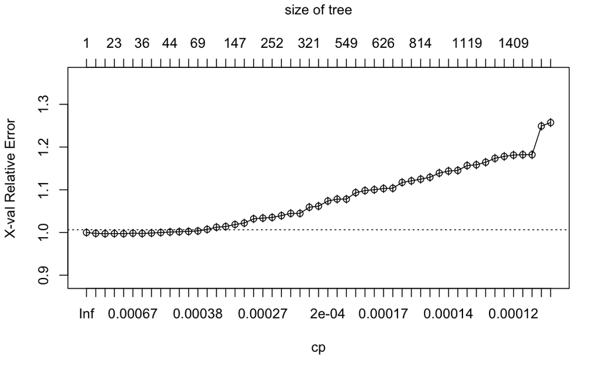

```r
control <- rpart.control(minbucket = 3, cp = 0.0001, maxsurrogate = 0, usesurrogate = 0, xval = 10)
tree_model <- rpart(DEP_DEL15~., data = train_data, method = "class", control = control)
plotcp(tree_model)
```

```r
best_cp <- tree_model$cptable[which.min(tree_model$cptable[, "xerror"]), "CP"]
prune_tree <- prune(tree_model, cp = best_cp)
prune_tree$variable.importance
```

```
 DEP_TIME_START            PRCP           MONTH  SEGMENT_NUMBER            TMAX            AWND  DISTANCE_GROUP NUMBER_OF_SEATS
     415.717343      197.426448       80.452264       66.508162       18.687511       18.057109        9.465581        7.450297
```

```r
cp_table_prune_tree = prune_tree$cptable[nrow(prune_tree$cptable),]
cp_table_prune_tree
```

```
          CP       nsplit    rel error       xerror         xstd
7.628929e-04 2.000000e+01 9.767063e-01 9.972536e-01 9.066056e-03
```

```r
missclassified_cv_tree <- cp_table_prune_tree['xerror'] * (1 - max(prop.table(table(df$DEP_DEL15))))
missclassified_cv_tree
```

```
   xerror
0.1897237
```

```r
test_preds <- predict(prune_tree, test_data, type = "class")

conf_matrix_test <- confusionMatrix(as.factor(test_preds), as.factor(test_data$DEP_DEL15), positive = "1")

tree_accuracy <- conf_matrix_test$overall["Accuracy"]
tree_precision <- conf_matrix_test$byClass["Precision"]
tree_recall <- conf_matrix_test$byClass["Recall"]
tree_f1 <- F1_Score(as.numeric(as.character(test_preds)),
                    as.numeric(as.character(test_data$DEP_DEL15)),
                    positive = "1")

print(paste("Test Set Accuracy:", round(tree_accuracy, 4)))
```

```
[1] "Test Set Accuracy: 0.8092"
```

```r
print(paste("Test Set Precision:", round(tree_precision, 4)))
```

```
[1] "Test Set Precision: 0.4856"
```

```r
print(paste("Test Set Recall:", round(tree_recall, 4)))
```

```
[1] "Test Set Recall: 0.048"
```

```r
print(paste("Test Set F1-Score:", round(tree_f1, 4)))
```

```
[1] "Test Set F1-Score: 0.0874"
```

```r
model_results_df <- add_model_results("Decision Tree", tree_accuracy, tree_precision, tree_recall, tree_f1)
```

The recall value is very low. I will try to balance the weight to understand better the data.

```r
tree_model_weighted <- rpart(DEP_DEL15 ~ ., data = df, method = "class",
                             control = rpart.control(cp = best_cp),
                             parms = list(loss = matrix(c(0, 2, 1, 0), nrow = 2)))
```

```r
weighted_preds <- predict(tree_model_weighted, test_data, type = "class")

conf_matrix_weighted <- confusionMatrix(as.factor(weighted_preds),
                                        as.factor(test_data$DEP_DEL15),
                                        positive = "1")

accuracy_weighted <- conf_matrix_weighted$overall["Accuracy"]
precision_weighted <- conf_matrix_weighted$byClass["Precision"]
recall_weighted <- conf_matrix_weighted$byClass["Recall"]
f1_score_weighted <- F1_Score(as.numeric(as.character(weighted_preds)),
                              as.numeric(as.character(test_data$DEP_DEL15)),
                              positive = "1")

print(paste("Weighted Decision Tree Test Accuracy:", round(accuracy_weighted, 4)))
```

```
[1] "Weighted Decision Tree Test Accuracy: 0.802"
```

```r
print(paste("Weighted Decision Tree Test Precision:", round(precision_weighted, 4)))
```

```
[1] "Weighted Decision Tree Test Precision: 0.4404"
```

```r
print(paste("Weighted Decision Tree Test Recall:", round(recall_weighted, 4)))
```

```
[1] "Weighted Decision Tree Test Recall: 0.1518"
```

```r
print(paste("Weighted Decision Tree Test F1-Score:", round(f1_score_weighted, 4)))
```

```
[1] "Weighted Decision Tree Test F1-Score: 0.2258"
```

```r
model_results_df <- add_model_results("Decision Tree Weighted", accuracy_weighted, precision_weighted, recall_weighted, f1_score_weighted)
```

### 4. Boosted Tree

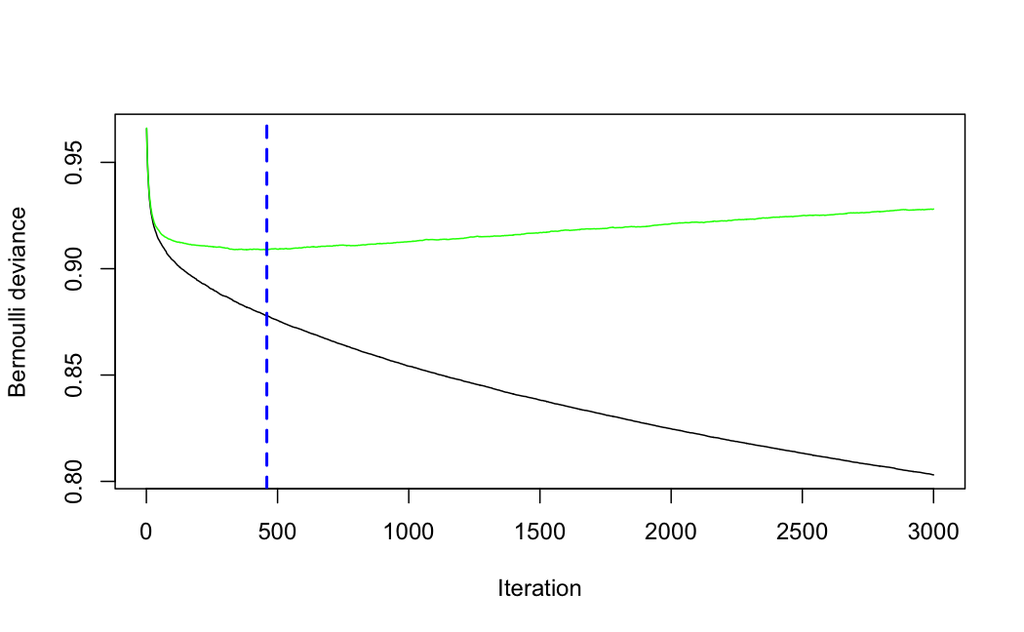

```r
gbm1 <- gbm(as.numeric(as.character(train_data$DEP_DEL15))~., data = train_data, distribution = "bernoulli", n.trees = 3000,
            shrinkage = 0.1, interaction.depth = 3, bag.fraction = 0.5, train.fraction = 1,
            n.minobsinnode = 10, cv.folds = 5, keep.data = TRUE, verbose = FALSE)
best.iter <- gbm.perf(gbm1, method = "cv")
```

```r
best.iter
```

```
[1] 459
```

|  | var | rel.inf |
| --- | --- | --- |
| DEP_TIME_START | DEP_TIME_START | 38.5457822 |
| MONTH | MONTH | 13.3842035 |
| PRCP | PRCP | 13.3547506 |
| SEGMENT_NUMBER | SEGMENT_NUMBER | 6.8414803 |
| DISTANCE_GROUP | DISTANCE_GROUP | 5.8266914 |
| TMAX | TMAX | 4.1259834 |
| GROUND_SERV_PER_PASS | GROUND_SERV_PER_PASS | 3.9699729 |
| DAY_OF_WEEK | DAY_OF_WEEK | 3.7261007 |
| AWND | AWND | 3.5704699 |
| NUMBER_OF_SEATS | NUMBER_OF_SEATS | 2.9049663 |

[output cut: 3 more lines]

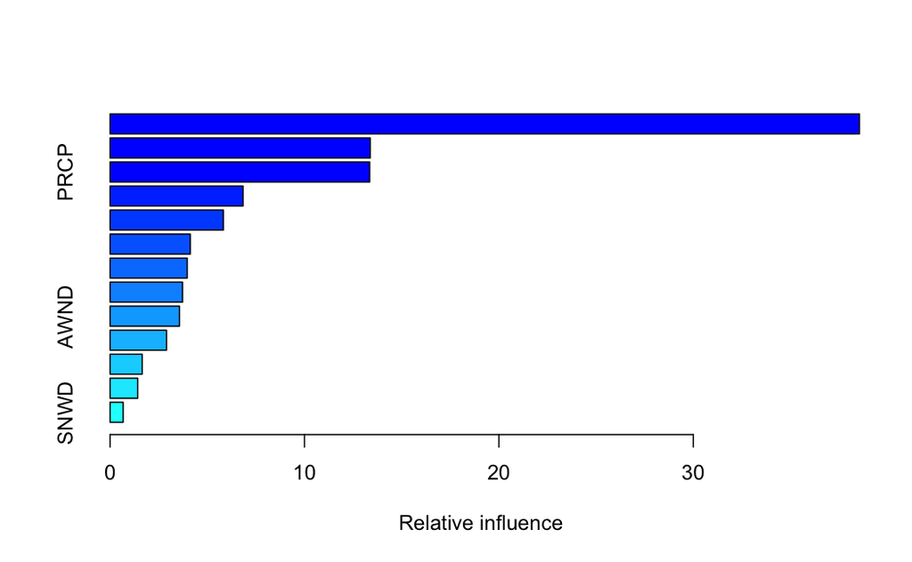

```r
summary(gbm1, n.trees = best.iter)
```

```r
gbm1_prob <- predict(gbm1, test_data, n.trees = best.iter, type = "response")
gbm1_pred <- ifelse(gbm1_prob > 0.5, 1, 0)

conf_matrix_gbm1 <- confusionMatrix(as.factor(gbm1_pred),
                                    as.factor(test_data$DEP_DEL15),
                                    positive = "1")

accuracy_gbm1 <- conf_matrix_gbm1$overall["Accuracy"]
precision_gbm1 <- conf_matrix_gbm1$byClass["Precision"]
recall_gbm1 <- conf_matrix_gbm1$byClass["Recall"]
f1_score_gbm1 <- F1_Score(as.numeric(as.character(gbm1_pred)),
                          as.numeric(as.character(test_data$DEP_DEL15)),
                          positive = "1")

print(paste("GBM Test Accuracy:", round(accuracy_gbm1, 4)))
```

```
[1] "GBM Test Accuracy: 0.8106"
```

```r
print(paste("GBM Test Precision:", round(precision_gbm1, 4)))
```

```
[1] "GBM Test Precision: 0.5242"
```

```r
print(paste("GBM Test Recall:", round(recall_gbm1, 4)))
```

```
[1] "GBM Test Recall: 0.0484"
```

```r
print(paste("GBM Test F1-Score:", round(f1_score_gbm1, 4)))
```

```
[1] "GBM Test F1-Score: 0.0887"
```

```r
model_results_df <- add_model_results("Boosted Tree", accuracy_gbm1, precision_gbm1, recall_gbm1, f1_score_gbm1)
```

From the result, it can be seen that the Boosted Tree is still struggling to predict the minority class, showed by the recall score.

#### Try to use class weight on GBM

```r
class_weights <- ifelse(train_data$DEP_DEL15 == 1, 2, 1)  # Adjust ratio (here is 5:1)

gbm2 <- gbm(as.numeric(as.character(train_data$DEP_DEL15)) ~ ., data = train_data,
            distribution = "bernoulli", n.trees = 3000, shrinkage = 0.1,
            interaction.depth = 3, bag.fraction = 0.5, train.fraction = 1,
            n.minobsinnode = 10, cv.folds = 5, keep.data = TRUE, verbose = FALSE,
            weights = class_weights)
```

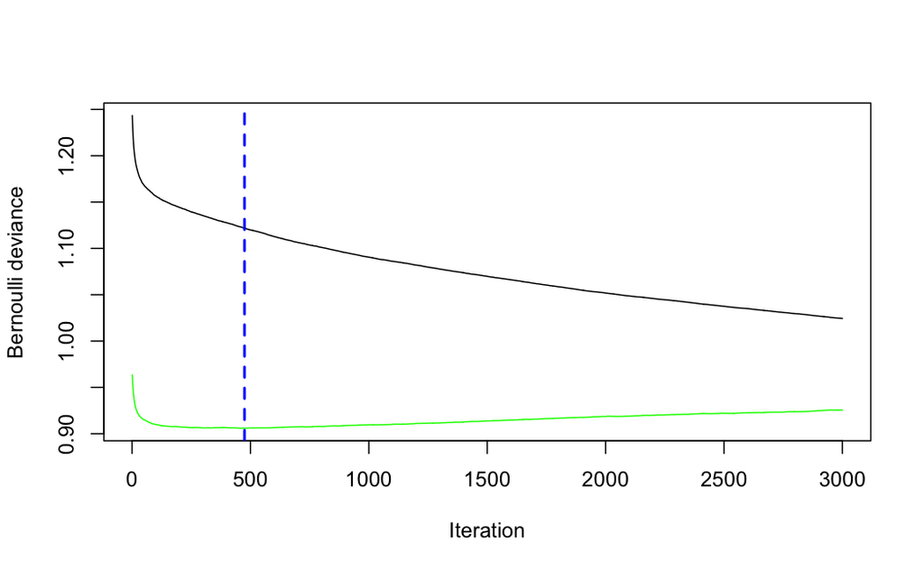

```r
best.iter2 <- gbm.perf(gbm2, method = "cv")
```

```r
best.iter2
```

```
[1] 475
```

```r
gbm2_prob <- predict(gbm2, test_data, n.trees = best.iter2, type = "response")
gbm2_pred <- ifelse(gbm2_prob > 0.5, 1, 0)

conf_matrix_gbm2 <- confusionMatrix(as.factor(gbm2_pred),
                                    as.factor(test_data$DEP_DEL15),
                                    positive = "1")

accuracy_gbm2 <- conf_matrix_gbm2$overall["Accuracy"]
precision_gbm2 <- conf_matrix_gbm2$byClass["Precision"]
recall_gbm2 <- conf_matrix_gbm2$byClass["Recall"]
f1_score_gbm2 <- F1_Score(as.numeric(as.character(gbm2_pred)),
                          as.numeric(as.character(test_data$DEP_DEL15)),
                          positive = "1")

print(paste("Weighted GBM Test Accuracy:", round(accuracy_gbm2, 4)))
```

```
[1] "Weighted GBM Test Accuracy: 0.7914"
```

```r
print(paste("Weighted GBM Test Precision:", round(precision_gbm2, 4)))
```

```
[1] "Weighted GBM Test Precision: 0.4093"
```

```r
print(paste("Weighted GBM Test Recall:", round(recall_gbm2, 4)))
```

```
[1] "Weighted GBM Test Recall: 0.2177"
```

```r
print(paste("Weighted GBM Test F1-Score:", round(f1_score_gbm2, 4)))
```

```
[1] "Weighted GBM Test F1-Score: 0.2843"
```

```r
model_results_df <- add_model_results("Boosted Tree Weighted Class", accuracy_gbm2, precision_gbm2, recall_gbm2, f1_score_gbm2)
```

### 5. Random Forest

```r
rf_model <- randomForest(DEP_DEL15 ~ ., data = train_data, mtry = 3, ntree = 500, importance = TRUE)
```

```r
rf_model
```

```
Call:
 randomForest(formula = DEP_DEL15 ~ ., data = train_data, mtry = 3,      ntree = 500, importance = TRUE)
               Type of random forest: classification
                     Number of trees: 500
No. of variables tried at each split: 3

        OOB estimate of  error rate: 18.83%
Confusion matrix:
      0   1 class.error
0 41109 733  0.01751828
1  8999 832  0.91536975
```

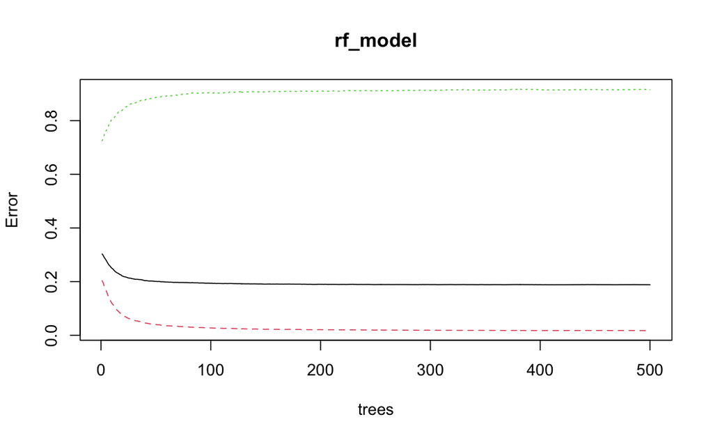

```r
plot(rf_model)
```

- Black line -> total error for all classes
- Red line -> OOB for majority class (class 0)
- Green line -> OOB for minority class (class 1)

```r
rf_preds <- predict(rf_model, test_data, type = "class")
conf_matrix_rf <- confusionMatrix(as.factor(rf_preds),
                                  as.factor(test_data$DEP_DEL15),
                                  positive = "1")

rf_accuracy <- conf_matrix_rf$overall["Accuracy"]
rf_precision <- conf_matrix_rf$byClass["Precision"]
rf_recall <- conf_matrix_rf$byClass["Recall"]
rf_f1 <- F1_Score(as.numeric(as.character(rf_preds)),
                  as.numeric(as.character(test_data$DEP_DEL15)),
                  positive = "1")

print(paste("Random Forest Test Accuracy:", round(rf_accuracy, 4)))
```

```
[1] "Random Forest Test Accuracy: 0.8121"
```

```r
print(paste("Random Forest Test Precision:", round(rf_precision, 4)))
```

```
[1] "Random Forest Test Precision: 0.5449"
```

```r
print(paste("Random Forest Test Recall:", round(rf_recall, 4)))
```

```
[1] "Random Forest Test Recall: 0.0741"
```

```r
print(paste("Random Forest Test F1-Score:", round(rf_f1, 4)))
```

```
[1] "Random Forest Test F1-Score: 0.1304"
```

```r
model_results_df <- add_model_results("Random Forest", rf_accuracy, rf_precision, rf_recall, rf_f1)
```

Highly bias to predict majority class. In here, I tried to give more weights for the minority class.

```r
# try to give more weights on the minority class
rf_model_weighted <- randomForest(DEP_DEL15 ~ ., data = train_data,
                                  mtry = 3, ntree = 500, importance = TRUE,
                                  classwt = c("0" = 1, "1" = 2))

rf_model_weighted
```

```
Call:
 randomForest(formula = DEP_DEL15 ~ ., data = train_data, mtry = 3,      ntree = 500, importance = TRUE, classwt = c(`0` = 1, `1` = 2))
               Type of random forest: classification
                     Number of trees: 500
No. of variables tried at each split: 3

        OOB estimate of  error rate: 18.91%
Confusion matrix:
      0   1 class.error
0 41456 386  0.00922518
1  9383 448  0.95442986
```

```r
rf_weighted_preds <- predict(rf_model_weighted, test_data, type = "class")
conf_matrix_rf_weighted <- confusionMatrix(as.factor(rf_weighted_preds),
                                           as.factor(test_data$DEP_DEL15),
                                           positive = "1")

rf_weighted_accuracy <- conf_matrix_rf_weighted$overall["Accuracy"]
rf_weighted_precision <- conf_matrix_rf_weighted$byClass["Precision"]
rf_weighted_recall <- conf_matrix_rf_weighted$byClass["Recall"]
rf_weighted_f1 <- F1_Score(as.numeric(as.character(rf_weighted_preds)),
                           as.numeric(as.character(test_data$DEP_DEL15)),
                           positive = "1")

print(paste("Weighted Random Forest Test Accuracy:", round(rf_weighted_accuracy, 4)))
```

```
[1] "Weighted Random Forest Test Accuracy: 0.8108"
```

```r
print(paste("Weighted Random Forest Test Precision:", round(rf_weighted_precision, 4)))
```

```
[1] "Weighted Random Forest Test Precision: 0.5394"
```

```r
print(paste("Weighted Random Forest Test Recall:", round(rf_weighted_recall, 4)))
```

```
[1] "Weighted Random Forest Test Recall: 0.0362"
```

```r
print(paste("Weighted Random Forest Test F1-Score:", round(rf_weighted_f1, 4)))
```

```
[1] "Weighted Random Forest Test F1-Score: 0.0679"
```

```r
model_results_df <- add_model_results("Random Forest Weighted", rf_weighted_accuracy, rf_weighted_precision, rf_weighted_recall, rf_weighted_f1)
```

```r
# try to give more weights on the minority class
rf_model_weighted2 <- randomForest(DEP_DEL15 ~ ., data = train_data,
                                  mtry = 3, ntree = 500, importance = TRUE,
                                  classwt = c("0" = 1, "1" = 3))

rf_model_weighted2
```

```
Call:
 randomForest(formula = DEP_DEL15 ~ ., data = train_data, mtry = 3,      ntree = 500, importance = TRUE, classwt = c(`0` = 1, `1` = 3))
               Type of random forest: classification
                     Number of trees: 500
No. of variables tried at each split: 3

        OOB estimate of  error rate: 18.95%
Confusion matrix:
      0   1 class.error
0 41474 368 0.008794991
1  9423 408 0.958498627
```

```r
rf_weighted_preds2 <- predict(rf_model_weighted2, test_data, type = "class")
conf_matrix_rf_weighted2 <- confusionMatrix(as.factor(rf_weighted_preds2),
                                           as.factor(test_data$DEP_DEL15),
                                           positive = "1")

rf_weighted_accuracy2 <- conf_matrix_rf_weighted2$overall["Accuracy"]
rf_weighted_precision2 <- conf_matrix_rf_weighted2$byClass["Precision"]
rf_weighted_recall2 <- conf_matrix_rf_weighted2$byClass["Recall"]
rf_weighted_f12 <- F1_Score(as.numeric(as.character(rf_weighted_preds2)),
                           as.numeric(as.character(test_data$DEP_DEL15)),
                           positive = "1")

print(paste("Weighted Random Forest Test Accuracy:", round(rf_weighted_accuracy2, 4)))
```

```
[1] "Weighted Random Forest Test Accuracy: 0.8103"
```

```r
print(paste("Weighted Random Forest Test Precision:", round(rf_weighted_precision2, 4)))
```

```
[1] "Weighted Random Forest Test Precision: 0.522"
```

```r
print(paste("Weighted Random Forest Test Recall:", round(rf_weighted_recall2, 4)))
```

```
[1] "Weighted Random Forest Test Recall: 0.0338"
```

```r
print(paste("Weighted Random Forest Test F1-Score:", round(rf_weighted_f12, 4)))
```

```
[1] "Weighted Random Forest Test F1-Score: 0.0635"
```

```r
model_results_df <- add_model_results("Random Forest Weighted 3:1", rf_weighted_accuracy2, rf_weighted_precision2, rf_weighted_recall2, rf_weighted_f12)
```

### 6. XGBoost

```r
# XGBoost requires matrix input
train_matrix <- model.matrix(DEP_DEL15 ~ ., data = train_data)[,-1]  # Remove intercept
train_label <- as.numeric(as.character(train_data$DEP_DEL15))

# Convert to XGBoost format
dtrain <- xgb.DMatrix(data = train_matrix, label = train_label)
```

```r
params <- list(
  objective = "binary:logistic",  # Binary classification
  eval_metric = "logloss",        # Logarithmic loss metric
  max_depth = 3,                  # Tree depth
  eta = 0.1,                      # Learning rate
  subsample = 0.8,                # Subsample ratio
  colsample_bytree = 0.8          # Column sampling
)

xgb_cv <- xgb.cv(
  params = params,
  data = dtrain,
  nrounds = 500,
  nfold = 5,
  stratified = TRUE,
  print_every_n = 10,
  early_stopping_rounds = 10
)
```

[output not shown]

```r
# Extract best number of rounds
best_nrounds <- xgb_cv$best_iteration
print(best_nrounds)
```

```
[1] 332
```

```r
# best iteration
xgb_model <- xgboost(
  params = params,
  data = dtrain,
  nrounds = best_nrounds,
  verbose = 0
)

# Convert test data into XGBoost matrix
test_matrix <- model.matrix(DEP_DEL15 ~ ., data = test_data)[,-1]
test_label <- as.numeric(as.character(test_data$DEP_DEL15))
dtest <- xgb.DMatrix(data = test_matrix, label = test_label)

xgb_probs <- predict(xgb_model, dtest)
xgb_preds <- ifelse(xgb_probs > 0.5, 1, 0)

conf_matrix_xgb <- confusionMatrix(as.factor(xgb_preds),
                                   as.factor(test_data$DEP_DEL15),
                                   positive = "1")

accuracy_xgb <- conf_matrix_xgb$overall["Accuracy"]
precision_xgb <- conf_matrix_xgb$byClass["Precision"]
recall_xgb <- conf_matrix_xgb$byClass["Recall"]
f1_score_xgb <- F1_Score(as.numeric(as.character(xgb_preds)),
                         as.numeric(as.character(test_data$DEP_DEL15)),
                         positive = "1")

print(paste("XGBoost Test Accuracy:", round(accuracy_xgb, 4)))
```

```
[1] "XGBoost Test Accuracy: 0.8099"
```

```r
print(paste("XGBoost Test Precision:", round(precision_xgb, 4)))
```

```
[1] "XGBoost Test Precision: 0.5033"
```

```r
print(paste("XGBoost Test Recall:", round(recall_xgb, 4)))
```

```
[1] "XGBoost Test Recall: 0.0313"
```

```r
print(paste("XGBoost Test F1-Score:", round(f1_score_xgb, 4)))
```

```
[1] "XGBoost Test F1-Score: 0.059"
```

```r
model_results_df <- add_model_results("XGBoost", accuracy_xgb, precision_xgb, recall_xgb, f1_score_xgb)
```

Try weighted model on xgboost

```r
params <- list(
  objective = "binary:logistic",
  eval_metric = "logloss",
  max_depth = 3,
  eta = 0.1,
  subsample = 0.8,
  colsample_bytree = 0.8,
  scale_pos_weight = 2  # 2:1 ratio for class 1
)

xgb_cv_weighted <- xgb.cv(
  params = params,
  data = dtrain,
  nrounds = 300,
  nfold = 5,
  stratified = TRUE,
  print_every_n = 10,
  early_stopping_rounds = 10
)
```

```
Multiple eval metrics are present. Will use test_logloss for early stopping.
Will train until test_logloss hasn't improved in 10 rounds.
```

```r
best_nrounds_weighted <- xgb_cv_weighted$best_iteration
print(paste("Best rounds with weighting:", best_nrounds_weighted))
```

```
[1] "Best rounds with weighting: 297"
```

```r
# best round
xgb_model_weighted <- xgboost(
  params = params,
  data = dtrain,
  nrounds = best_nrounds_weighted,
  verbose = 0
)

xgb_probs_weighted <- predict(xgb_model_weighted, dtest)
xgb_preds_weighted <- ifelse(xgb_probs_weighted > 0.5, 1, 0)

conf_matrix_xgb_weighted <- confusionMatrix(as.factor(xgb_preds_weighted),
                                            as.factor(test_data$DEP_DEL15),
                                            positive = "1")

accuracy_xgb_weighted <- conf_matrix_xgb_weighted$overall["Accuracy"]
precision_xgb_weighted <- conf_matrix_xgb_weighted$byClass["Precision"]
recall_xgb_weighted <- conf_matrix_xgb_weighted$byClass["Recall"]
f1_score_xgb_weighted <- F1_Score(as.numeric(as.character(xgb_preds_weighted)),
                                  as.numeric(as.character(test_data$DEP_DEL15)),
                                  positive = "1")

print(paste("Weighted XGBoost Test Accuracy:", round(accuracy_xgb_weighted, 4)))
```

```
[1] "Weighted XGBoost Test Accuracy: 0.7965"
```

```r
print(paste("Weighted XGBoost Test Precision:", round(precision_xgb_weighted, 4)))
```

```
[1] "Weighted XGBoost Test Precision: 0.4183"
```

```r
print(paste("Weighted XGBoost Test Recall:", round(recall_xgb_weighted, 4)))
```

```
[1] "Weighted XGBoost Test Recall: 0.1791"
```

```r
print(paste("Weighted XGBoost Test F1-Score:", round(f1_score_xgb_weighted, 4)))
```

```
[1] "Weighted XGBoost Test F1-Score: 0.2508"
```

```r
model_results_df <- add_model_results("XGBoost Weighted Ration 2:1", accuracy_xgb_weighted, precision_xgb_weighted, recall_xgb_weighted, f1_score_xgb_weighted)
```

```r
# Load DT package
library(DT)
# Display table with pagination
datatable(model_results_df,
          options = list(pageLength = nrow(model_results_df)),  # Show all rows
          rownames = FALSE)
```

| Model | Accuracy | Precision | Recall | F1_Score |
| --- | --- | --- | --- | --- |
| Logistic Regression | 0.8099 | 0.5085 | 0.0122 | 0.0238 |
| Neural Network | 0.81 | 0.5053 | 0.0578 | 0.1037 |
| Decision Tree | 0.8092 | 0.4856 | 0.048 | 0.0874 |
| Decision Tree Weighted | 0.802 | 0.4404 | 0.1518 | 0.2258 |
| Boosted Tree | 0.8106 | 0.5242 | 0.0484 | 0.0887 |
| Boosted Tree Weighted Class | 0.7914 | 0.4093 | 0.2177 | 0.2843 |
| Random Forest | 0.8121 | 0.5449 | 0.0741 | 0.1304 |
| Random Forest Weighted | 0.8108 | 0.5394 | 0.0362 | 0.0679 |
| Random Forest Weighted 3:1 | 0.8103 | 0.522 | 0.0338 | 0.0635 |
| XGBoost | 0.8099 | 0.5033 | 0.0313 | 0.059 |

[output cut: 1 more lines]